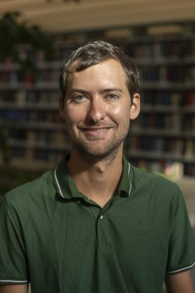

# Matt Higham

## Bio

Matt Higham studies spatial statistics with ecological applications. His focus is spatial prediction models with imperfect detection of animals in surveys. He is an Assistant Professor at St. Lawrence University and earned a PhD degree in Statistics from Oregon State University in 2019 and B.S. degrees in Statistics and Botany from Miami University in 2014.

He is a co-author on the `R` package `spmodel`, used for spatial modeling and prediction. Workshop materials for `spmodel` from the 2023 *Spatial Statistics* conference can be found [here](https://usepa.github.io/spmodel.spatialstat2023/).

## Teaching

At St. Lawrence University, I regularly teach the following courses:

- Introduction to Statistics
- Applied Regression Modeling
- [Foundations of Data Science](https://highamm.github.io/ds234_quarto/)
- [Data Visualization](https://highamm.github.io/dataviz334/)

## Recent Scholarly Work

- Dumelle, M., Ver Hoef, J. M., Handler, A., Hill, R. A., **Higham, M.**, & Olsen, A. R. (2024). Modeling lake conductivity in the contiguous United States using spatial indexing for big spatial data. *Spatial Statistics*, *59*: 100808. [Link to Paper](https://www.sciencedirect.com/science/article/pii/S2211675323000830).
- Ver Hoef, J. M., Dumelle, M., **Higham, M.**, Peterson, E., & Isaak, D. (2023). Indexing and partitioning the spatial linear model for large data sets. *Plos one*, *18*(11), e0291906. [Link to Paper](https://doi.org/10.1371/journal.pone.0291906).
- **Higham, M.**, Dumelle, M., Hammond, C., Ver Hoef, J. M., & Wells, J. (2023). An application of spatio-temporal modeling to finite population abundance prediction. *Journal of Agricultural, Biological and Environmental Statistics*, 1 - 25. [Link to Paper](https://link.springer.com/article/10.1007/s13253-023-00565-y).
- **Higham, M.**, Ver Hoef, J., Frank, B., & Dumelle, M. (2023). `sptotal`: an `R` package for predicting totals and weighted sums from spatial data. *Journal of Open Source Software*, *8*(85). [Link to Paper](https://joss.theoj.org/papers/10.21105/joss.05363.pdf).
- Dumelle, M., **Higham, M.**, & Ver Hoef, J. M. (2023). `spmodel`: Spatial statistical modeling and prediction in `R`. *Plos one*, *18*(3), e0282524. [Link to Paper](https://journals.plos.org/plosone/article?id=10.1371/journal.pone.0282524).
- Dumelle, M., **Higham, M.**, Ver Hoef, J. M., Olsen, A. R., & Madsen, L. (2022). A comparison of design-based and model-based approaches for finite population spatial sampling and inference. *Methods in Ecology and Evolution*, 00, 1 – 12. [Link to GitHub](https://github.com/USEPA/DvMsp).
- Ver Hoef, J., Johnson, D., Angliss, R., & **Higham, M**. (2021). Species density models from opportunistic citizen science data. *Methods in Ecology and Evolution*. [Link to GitHub](https://github.com/highamm/POP).
- **Higham, M.**, Ver Hoef, J., Madsen, L., & Aderman, A. (2021). Adjusting a finite population block kriging estimator for imperfect detection. *Environmetrics*, **32**(1), e2654. [Link to Paper](https://onlinelibrary.wiley.com/doi/epdf/10.1002/env.2654).

## Other

In my free time, I enjoy playing racket sports 🎾, jogging 🏃, gaming 🎮, hiking ⛰, and backpacking 🎒!